# BTS 510 Lab 8

```r
set.seed(12345)
library(tidyverse)
library(Stat2Data)
theme_set(theme_classic(base_size = 16))
```

## 1 Learning objectives

- **Assess** models for **(multi)collinearity** among predictors
- **Conduct** outlier analyses to determine extreme and/or problematic cases

## 2 Data

- `FirstYearGPA` data from the **Stat2Data** package: $n$ = 219 subjects
  - `GPA`: First-year college GPA on a 0.0 to 4.0 scale
  - `HSGPA`: High school GPA on a 0.0 to 4.0 scale
  - `SATV`: Verbal/critical reading SAT score
  - `SATM`: Math SAT score
  - `Male`: 1= male, 0= female
  - `HU`: Number of credit hours earned in humanities courses in high school
  - `SS`: Number of credit hours earned in social science courses in high school
  - `FirstGen`: 1= student is the first in her or his family to attend college, 0=otherwise
  - `White`: 1= white students, 0= others
  - `CollegeBound`: 1=attended a high school where >=50% students intended to go on to college, 0=otherwise

## 3 Research question(s)

- How do **all these variables** impact first year GPA (`GPA`)?
  - Are there any problems with **collinearity** among the *predictors*?
  - Are there **problematic cases** that are *influencing the results*?

## 4 Tasks

### 4.1 Model

1. Run a **linear regression model** predicting `GPA` from *all other variables* in the dataset.

```r
library(tidyverse)
library(Stat2Data)
data(FirstYearGPA)
m1 <- lm(data = FirstYearGPA, GPA ~ .)
summary(m1)
```

```
Call:
lm(formula = GPA ~ ., data = FirstYearGPA)

Residuals:
     Min       1Q   Median       3Q      Max
-1.07412 -0.25827  0.05384  0.27675  0.85761

Coefficients:
               Estimate Std. Error t value Pr(>|t|)
(Intercept)   0.5268983  0.3487584   1.511  0.13235
HSGPA         0.4932945  0.0745553   6.616 3.03e-10 ***
SATV          0.0005919  0.0003945   1.501  0.13498
SATM          0.0000847  0.0004447   0.190  0.84912
Male          0.0482478  0.0570277   0.846  0.39850
HU            0.0161874  0.0039723   4.075 6.53e-05 ***
SS            0.0073370  0.0055635   1.319  0.18869
FirstGen     -0.0743417  0.0887490  -0.838  0.40318
White         0.1962316  0.0700182   2.803  0.00555 **
CollegeBound  0.0214530  0.1003350   0.214  0.83090
---
Signif. codes:  0 '***' 0.001 '**' 0.01 '*' 0.05 '.' 0.1 ' ' 1

Residual standard error: 0.3834 on 209 degrees of freedom
Multiple R-squared:  0.3496,    Adjusted R-squared:  0.3216
F-statistic: 12.48 on 9 and 209 DF,  p-value: 8.674e-16
```

### 4.2 Correlations and VIFs

2. Some of those variables seem like they could be **strongly related**, which could cause problems for the model. Check to see if **collinearity** is an issue for this model. To check this, look at:
- **Correlations among variables**
- **Variable inflation factors (VIFs)**

```r
cor(FirstYearGPA)
```

```
                     GPA       HSGPA        SATV         SATM        Male
GPA           1.00000000  0.44688735  0.30431137  0.194343851  0.05284917
HSGPA         0.44688735  1.00000000  0.21032124  0.152839634 -0.09031714
SATV          0.30431137  0.21032124  1.00000000  0.526943819  0.14555703
SATM          0.19434385  0.15283963  0.52694382  1.000000000  0.37099167
Male          0.05284917 -0.09031714  0.14555703  0.370991668  1.00000000
HU            0.31465575  0.11603117  0.09874856 -0.009601549 -0.01884386
SS           -0.00356909 -0.01725443 -0.02646987 -0.087839974  0.03507603
FirstGen     -0.15657732  0.06418575 -0.25657713 -0.177387395 -0.07610526
White         0.28177214  0.04604668  0.36823365  0.259465227  0.07696022
CollegeBound -0.06302497 -0.20003903  0.06484473  0.039322063  0.09981773
                       HU          SS    FirstGen       White CollegeBound
GPA           0.314655754 -0.00356909 -0.15657732  0.28177214  -0.06302497
HSGPA         0.116031169 -0.01725443  0.06418575  0.04604668  -0.20003903
SATV          0.098748556 -0.02646987 -0.25657713  0.36823365   0.06484473
SATM         -0.009601549 -0.08783997 -0.17738739  0.25946523   0.03932206
Male         -0.018843863  0.03507603 -0.07610526  0.07696022   0.09981773
HU            1.000000000 -0.30660787 -0.21256561  0.12593391  -0.02997230
SS           -0.306607866  1.00000000 -0.02366326  0.01673417  -0.03170649
FirstGen     -0.212565615 -0.02366326  1.00000000 -0.23790392  -0.11051100
White         0.125933908  0.01673417 -0.23790392  1.00000000  -0.02391156
CollegeBound -0.029972303 -0.03170649 -0.11051100 -0.02391156   1.00000000
```

```r
library(car)
vif(m1)
```

```
       HSGPA         SATV         SATM         Male           HU           SS
    1.158078     1.605182     1.660002     1.205737     1.221530     1.147867
    FirstGen        White CollegeBound
    1.186760     1.212049     1.073989
```

- None of the variables show pronounced variance inflation
  - All VIFs < 5
  - Even though the variables are correlated, they’re not all correlated to a degree that they’re affecting the variance (i.e., standard error)

### 4.3 Thoughts

3. Based on the **correlations between each predictor and the outcome** (above), are there predictors that you think **should** be significant but aren’t? Why do you think they aren’t? (This is a bit of a philosophical question.)
- One thought is that the two SAT scores are too correlated with each other and might be significant if they were combined
  - (But education research generally shows that they’re not super predictive of college GPA after you account for other things like HS GPA and demographics. This is part of the argument for some schools dropping SAT requirements.)

### 4.4 Outliers

4. Are there **extreme cases** that we might be concerned about? Check for extreme values in terms of:
- **Predictors**
- **Predicted values**
- **Changes to predicted values**

#### 4.4.1 Leverage (predictors)

- Note that the cut-offs are
  - Larger samples: $\frac{2(k+1)}{n}$
  - Smaller samples: $\frac{3(k+1)}{n}$
  - where $k$ = number of predictors and $n$ = sample size
- This dataset didn’t have an ID variable, so I added on that’s basically the row number
  - `m1_aug <- m1_aug %>% mutate(ID = 1:nrow(m1_aug))`
  - Add a variable called `ID` to the data frame `m1_aug`
  - The new variable is just a sequential number that starts at 1 and ends at `nrow(m1_aug)` (the number of rows in the dataset)

```r
library(broom)
m1_aug <- augment(m1)
m1_aug
```

```
# A tibble: 219 × 16
     GPA HSGPA  SATV  SATM  Male    HU    SS FirstGen White CollegeBound .fitted
   <dbl> <dbl> <int> <int> <int> <dbl> <dbl>    <int> <int>        <int>   <dbl>
 1  3.06  3.83   680   770     1   3     9          1     1            1    3.19
 2  4.15  4      740   720     0   9     3          0     1            1    3.38
 3  3.41  3.7    640   570     0  16    13          0     0            1    3.16
 4  3.21  3.51   740   700     0  22     0          0     1            1    3.33
 5  3.48  3.83   610   610     0  30.5   1.5        0     1            1    3.55
 6  2.95  3.25   600   570     0  18     3          0     1            1    3.06
 7  3.6   3.79   710   630     0   5    19          0     1            1    3.31
 8  2.87  3.6    390   570     0  10     0          0     0            0    2.74
 9  3.67  3.36   630   560     0   8.5  15.5        0     1            1    3.07
10  3.49  3.7    680   670     0  16    12          0     1            1    3.38
# ℹ 209 more rows
# ℹ 5 more variables: .resid <dbl>, .hat <dbl>, .sigma <dbl>, .cooksd <dbl>,
#   .std.resid <dbl>
```

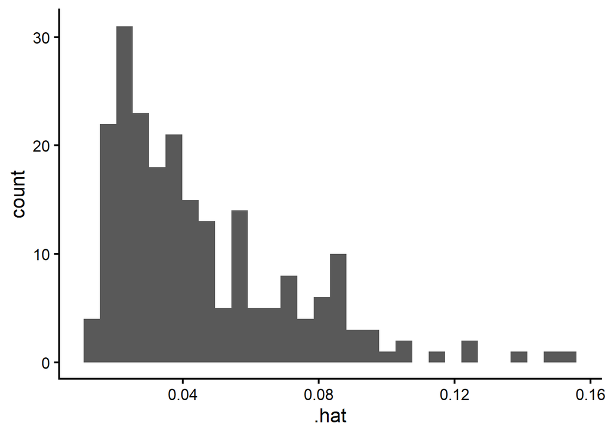

```r
ggplot(data = m1_aug,
       aes(x = .hat)) +
  geom_histogram()
```

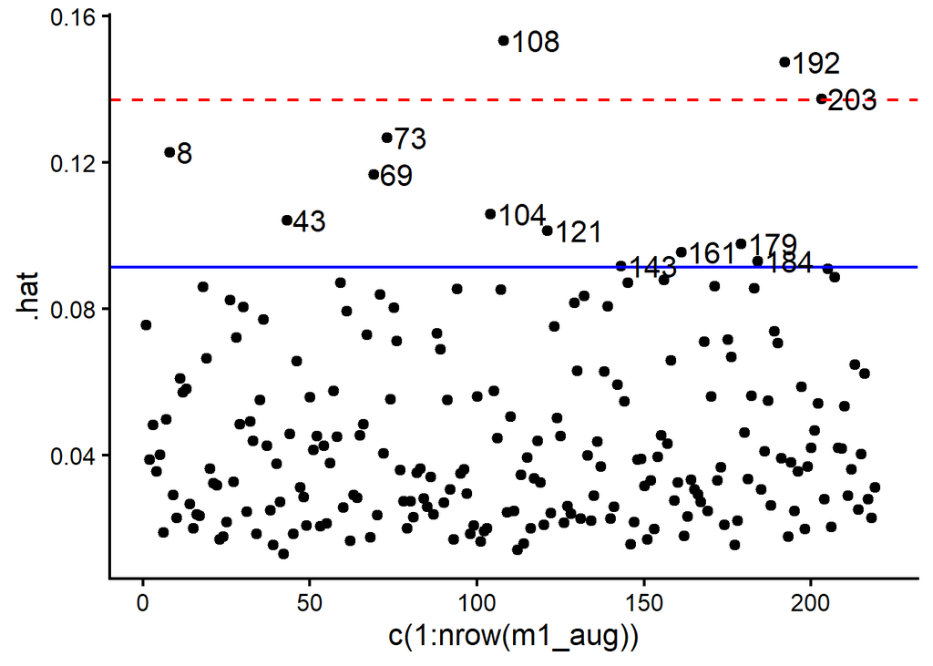

```r
m1_aug <- m1_aug %>% mutate(ID = 1:nrow(m1_aug))
ggplot(data = m1_aug,
       aes(x = c(1:nrow(m1_aug)),
           y = .hat)) +
  geom_point() +
  geom_hline(yintercept = 3*(9+1)/219,
             color = "red",
             linetype = "dashed") +
  geom_hline(yintercept = 2*(9+1)/219,
             color = "blue") +
  geom_text(aes(label=ifelse((.hat > 2*(9+1)/219),
                             as.character(ID),
                             '')),
            hjust = 0, nudge_x = 2)
```

#### 4.4.2 Discrepancy (residuals)

```r
library(car)
m1_stresid <- FirstYearGPA %>% mutate(esresid = rstudent(m1))
head(m1_stresid)
```

```
   GPA HSGPA SATV SATM Male   HU   SS FirstGen White CollegeBound    esresid
1 3.06  3.83  680  770    1  3.0  9.0        1     1            1 -0.3523421
2 4.15  4.00  740  720    0  9.0  3.0        0     1            1  2.0524744
3 3.41  3.70  640  570    0 16.0 13.0        0     0            1  0.6808208
4 3.21  3.51  740  700    0 22.0  0.0        0     1            1 -0.3167075
5 3.48  3.83  610  610    0 30.5  1.5        0     1            1 -0.1895846
6 2.95  3.25  600  570    0 18.0  3.0        0     1            1 -0.3012032
```

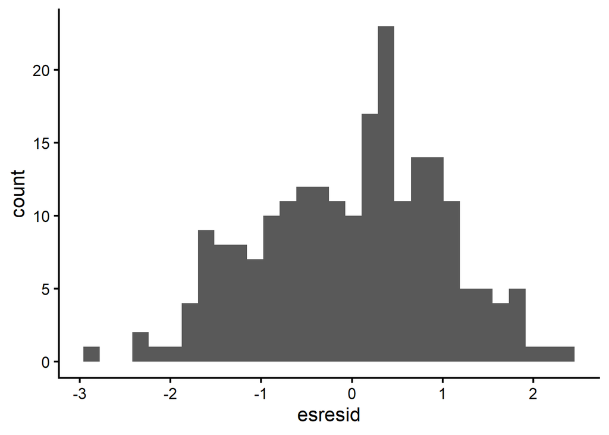

```r
ggplot(data = m1_stresid,
       aes(x = esresid)) +
  geom_histogram()
```

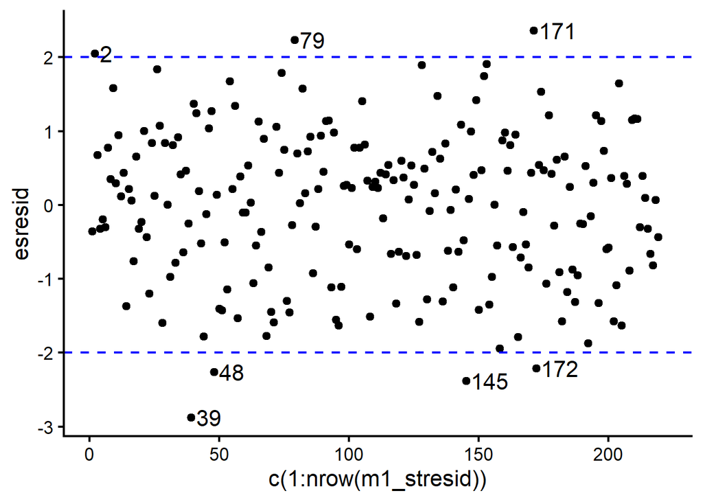

```r
m1_stresid <- m1_stresid %>% mutate(ID = 1:nrow(m1_stresid))
ggplot(data = m1_stresid,
       aes(x = c(1:nrow(m1_stresid)),
           y = esresid)) +
  geom_point() +
  geom_hline(yintercept = 2,
             color = "blue",
             linetype = "dashed") +
  geom_hline(yintercept = -2,
             color = "blue",
             linetype = "dashed") +
  geom_text(aes(label=ifelse((esresid > 2),
                             as.character(ID),
                             '')),
            hjust = 0, nudge_x = 2) +
  geom_text(aes(label=ifelse((esresid < -2),
                             as.character(ID),
                             '')),
            hjust = 0, nudge_x = 2)
```

#### 4.4.3 Influence (Cook’s d – change coefficients)

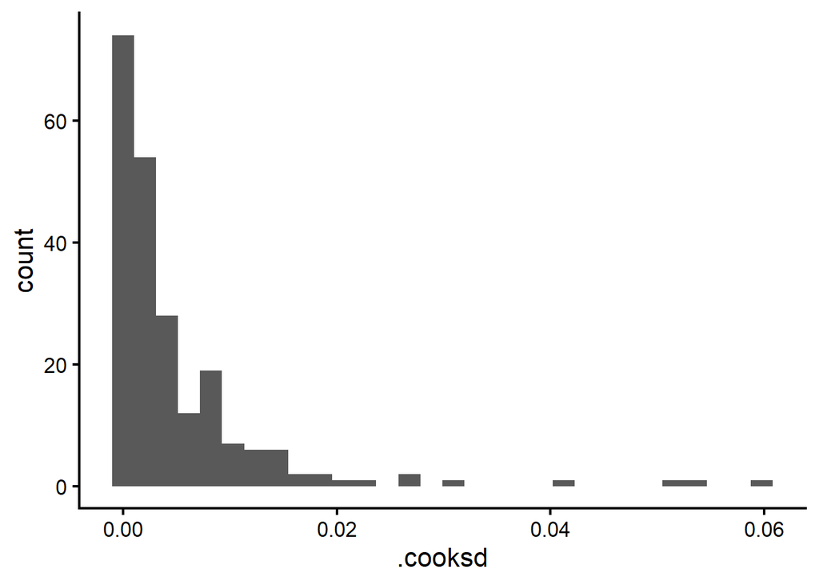

```r
ggplot(data = m1_aug,
       aes(x = .cooksd)) +
  geom_histogram()
```

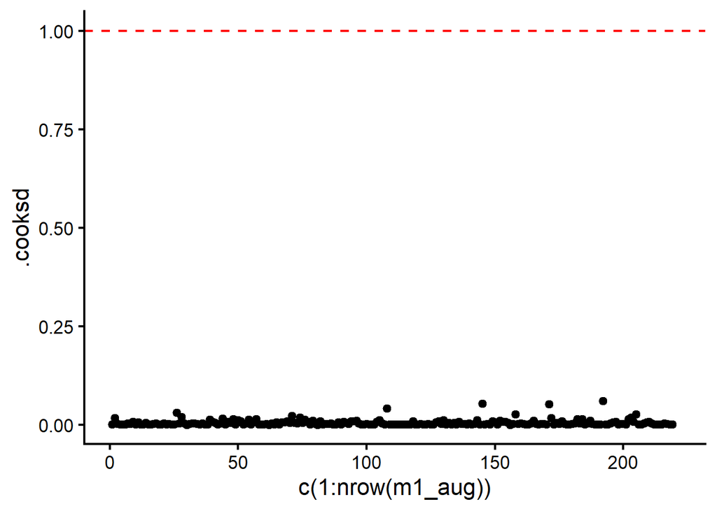

```r
ggplot(data = m1_aug,
       aes(x = c(1:nrow(m1_aug)),
           y = .cooksd)) +
  geom_point() +
  geom_hline(yintercept = 1,
             color = "red",
             linetype = "dashed") +
  geom_text(aes(label=ifelse((.cooksd > 1),
                             as.character(ID),
                             '')),
            hjust = 0, nudge_x = 2)
```

#### 4.4.4 Summary of outliers

```r
m1_aug %>% filter(.hat > 2*(9+1)/219) %>% select(ID)
```

```
# A tibble: 13 × 1
      ID
   <int>
 1     8
 2    43
 3    69
 4    73
 5   104
 6   108
 7   121
 8   143
 9   161
10   179
11   184
12   192
13   203
```

```r
m1_aug %>% filter(.hat > 3*(9+1)/219) %>% select(ID)
```

```
# A tibble: 3 × 1
     ID
  <int>
1   108
2   192
3   203
```

- Repeat offenders (discrepency)

```r
m1_stresid %>% filter(esresid > 2) %>% select(ID)
```

```
   ID
1   2
2  79
3 171
```

```r
m1_stresid %>% filter(esresid < -2) %>% select(ID)
```

```
   ID
1  39
2  48
3 145
4 172
```

- Repeat offenders (influence)

```r
m1_aug %>% filter(.cooksd > 1) %>% select(ID)
```

```
# A tibble: 0 × 1
# ℹ 1 variable: ID <int>
```

### 4.5 Summary

5. **Summarize** your findings about collinearity and outliers. *Use plain language.*
- Collinearity
  - Some of the predictors are moderately correlated, so we could consider combining or dropping some
  - The correlations among predictors are not inflating the standard errors of the regression coefficient though, based on all VIFs < 5
- Outliers
  - Between 3 and 13 observations were extreme on the predictors (leverage), depending on the cut off used
  - 7 observations had extreme (externally studentized) residuals (discrepancy), meaning that the predicted outcome value was very different from the observed outcome value
  - No observations were changing the predicted values notably (influence)
  - There was no overlap in the observations with high leverage and high discrepancy, and there were no observations with high influence, so there are no extreme observations of concern